# summary of poisson

2024-11-07

# 1 Preliminaries

```r
### Load libraries
rm(list=ls())
library(survival)
library(splines)
library(rms)
```

```r
library(ggplot2)

### Load functions I have written for assessing calibration, estimating true calibration curve for simulated data, etc
source(file.path("..", "..", "R/functions.R"))

### Read in data
dat.devel <- readRDS(file.path("..", "..", "data/reproducible_example_dat_nocens.rds"))
str(dat.devel)
```

```
## 'data.frame':    100000 obs. of  11 variables:
##  $ id            : int  1 2 3 4 5 6 7 8 9 10 ...
##  $ time          : num  0.498 2.773 0.212 0.4 3.219 ...
##  $ status        : int  1 1 1 1 1 1 1 1 1 1 ...
##  $ cens_time     : num  0.498 2.773 0.212 0.4 3.219 ...
##  $ cens_indicator: num  0 0 0 0 0 0 0 0 0 0 ...
##  $ x1            : num  -1.121 -1.282 -2.039 -0.938 -0.51 ...
##  $ x2            : num  -2.141 -1.364 0.647 -0.075 -0.555 ...
##  $ x3            : num  -0.0232 -0.4046 0.9796 1.4968 0.2914 ...
##  $ x2sq          : num  4.58257 1.86088 0.41813 0.00563 0.30779 ...
##  $ x3cu          : num  -1.25e-05 -6.62e-02 9.40e-01 3.35 2.47e-02 ...
##  $ true.lp       : num  0.649 -0.608 0.191 0.915 -0.228 ...
```

```r
### Read in data
dat.valid <- readRDS(file.path("..", "..", "data/reproducible_example_dat_cens.rds"))
str(dat.valid)
```

```
## 'data.frame':    100000 obs. of  11 variables:
##  $ id            : int  1 2 3 4 5 6 7 8 9 10 ...
##  $ time          : num  0.0642 1.0502 0.2116 0.3997 0.3868 ...
##  $ status        : num  0 0 1 1 0 0 0 1 1 1 ...
##  $ x1            : num  -1.121 -1.282 -2.039 -0.938 -0.51 ...
##  $ x2            : num  -2.141 -1.364 0.647 -0.075 -0.555 ...
##  $ x3            : num  -0.0232 -0.4046 0.9796 1.4968 0.2914 ...
##  $ x2sq          : num  4.58257 1.86088 0.41813 0.00563 0.30779 ...
##  $ x3cu          : num  -1.25e-05 -6.62e-02 9.40e-01 3.35 2.47e-02 ...
##  $ cens_time     : num  0.0642 1.0502 0.2116 0.3997 0.3868 ...
##  $ cens_indicator: num  1 1 0 0 1 1 1 0 0 0 ...
##  $ true.lp       : num  0.649 -0.608 0.191 0.915 -0.228 ...
```

```r
dat.valid <- subset(dat.valid, id != 21075)
t.eval <- 0.5

### Censor at time t.eval
dat.devel <- dplyr::mutate(dat.devel,
                           status = dplyr::case_when(time > t.eval ~ 0,
                                                     TRUE ~ status),
                           time = dplyr::case_when(time > t.eval ~ t.eval,
                                                   TRUE ~ time))

### Censor at time t.eval
dat.valid <- dplyr::mutate(dat.valid,
                           status = dplyr::case_when(time > t.eval ~ 0,
                                                     TRUE ~ status),
                           time = dplyr::case_when(time > t.eval ~ t.eval,
                                                   TRUE ~ time))

str(dat.valid)
```

```
## 'data.frame':    99999 obs. of  11 variables:
##  $ id            : int  1 2 3 4 5 6 7 8 9 10 ...
##  $ time          : num  0.0642 0.5 0.2116 0.3997 0.3868 ...
##  $ status        : num  0 0 1 1 0 0 0 1 1 1 ...
##  $ x1            : num  -1.121 -1.282 -2.039 -0.938 -0.51 ...
##  $ x2            : num  -2.141 -1.364 0.647 -0.075 -0.555 ...
##  $ x3            : num  -0.0232 -0.4046 0.9796 1.4968 0.2914 ...
##  $ x2sq          : num  4.58257 1.86088 0.41813 0.00563 0.30779 ...
##  $ x3cu          : num  -1.25e-05 -6.62e-02 9.40e-01 3.35 2.47e-02 ...
##  $ cens_time     : num  0.0642 1.0502 0.2116 0.3997 0.3868 ...
##  $ cens_indicator: num  1 1 0 0 1 1 1 0 0 0 ...
##  $ true.lp       : num  0.649 -0.608 0.191 0.915 -0.228 ...
```

Fit a non-linear model with the appropriate non-linear terms (x2 squared and x3 cubed) and check the coefficients match 0.5, 0.5, 0.5, 0.5 and 0.2. Hopefully this proves that the data generating mechanism is as described above.

```r
### Fit non-linear model
fit.nl <- coxph(Surv(time, status) ~ x1 + x2 + x2sq + x3 + x3cu, data = dat.devel)
coefficients(fit.nl)
```

```
##        x1        x2      x2sq        x3      x3cu
## 0.4923671 0.4950808 0.5012444 0.5064175 0.1972879
```

# 2 Examples using multiple linear model (poorly specified)

## 2.1 Fit model

```r
### Fit non-linear model
fit.ml <- coxph(Surv(time, status) ~ x1 + x2 + x3, data = dat.devel)
coefficients(fit.ml)
```

```
##        x1        x2        x3
## 0.4182499 0.5190276 0.8449995
```

```r
### Calculate baseline hazard
bhaz.ml <- basehaz(fit.ml, centered = TRUE)
```

## 2.2 Assess calibraiton using proportional hazards approach and true calibration curve

We can see calibration according to the proportional hazards approach, and also add the ‘true’ calibration curve estimated by regressing true risk (from DGM) on predicted risk.

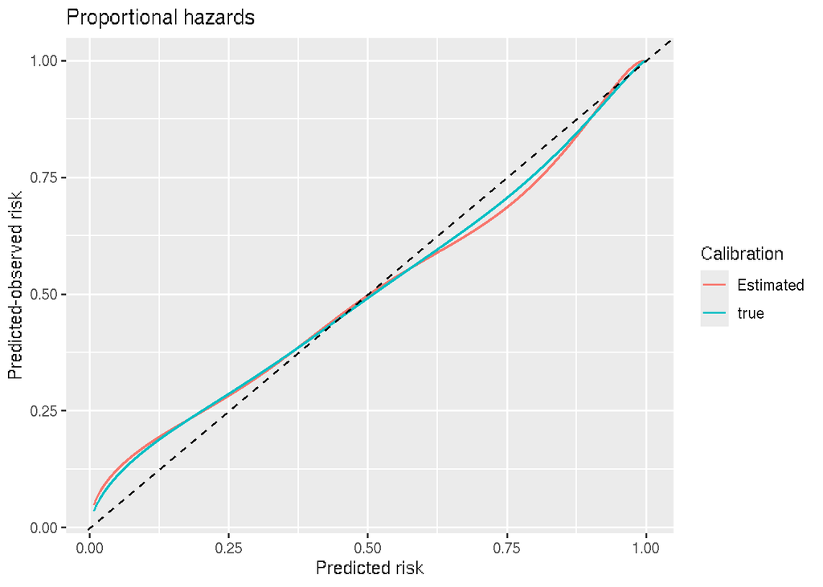

```r
### Estimate calibration plot using proportional-hazards approach
calib.ph <- est_calib_ph(data = dat.valid, fit  = fit.ml, bhaz = bhaz.ml, t = t.eval, nk = 5)

### Estimate true calibration curve
calib.true <- est_calib_true(data = dat.valid,
                             fit = fit.ml,
                             bhaz = bhaz.ml,
                             t = t.eval,
                             true.lp = dat.valid$true.lp,
                             cumhaz.t = 0.5)

### Add to the plot
calib.ph <- add_calib_true(calib.ph, calib.true)

### Print the plot
calib.ph[["plot"]]
```

## 2.3 Assess calibration using smoothed Poisson methods

Now lets assess calibration using the approach in the Terry vignette.

```r
### Estimate predicted risks
dat.valid$eta <- predict(fit.ml, newdata = dat.valid, type = "lp")

### Get expected number of events
dat.valid$expect1 <- predict(fit.ml, type = "expected", newdata = dat.valid)

### Fit calibration model for mean calibraiton
gfit1 <- glm(status ~ offset(log(expect1)), poisson, data = dat.valid)
exp(coef(gfit1))
```

```
## (Intercept)
##    1.000176
```

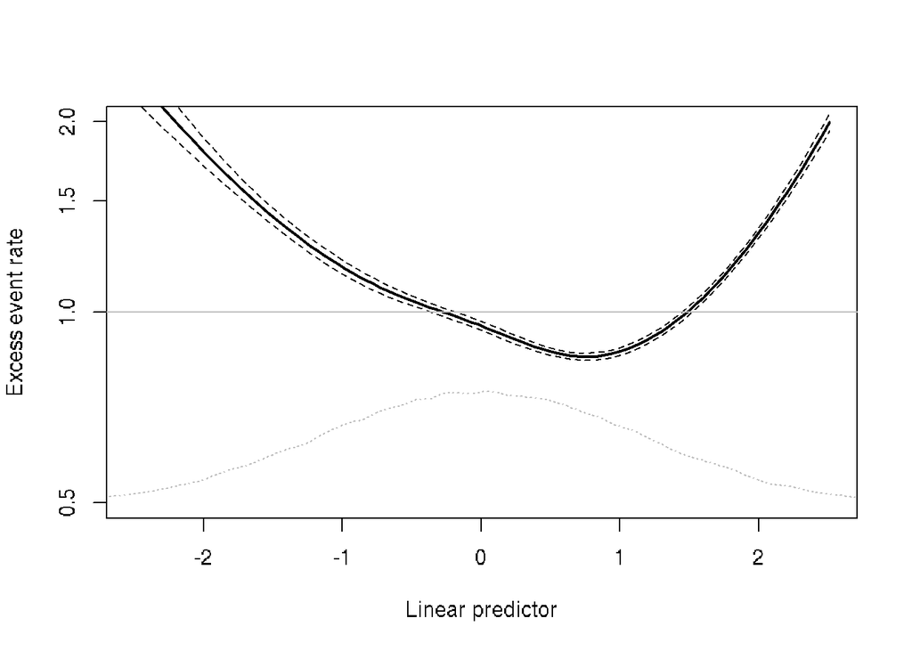

```r
### Now lets get a plot of excess event rates on the y-axis, vs linear predictor on the x-axis
# gfit_flex <- glm(status ~ ns(eta, 4) + offset(log(expect1)), poisson, data = dat.valid)
gfit_flex <- update(gfit1, . ~ . + ns(eta, 4))
xx <- seq(as.numeric(quantile(dat.valid$eta, p = 0.01)), as.numeric(quantile(dat.valid$eta, p = 0.99)), length=100)
yhat <- predict(gfit_flex, newdata= data.frame(eta=xx, expect1=1), se=TRUE)
yy <- yhat$fit + outer(yhat$se.fit, c(0, -1.96, 1.96), '*')

matplot(xx, exp(yy), type='l', lty=c(1,2,2), lwd=c(2,1,1), log='y', col=1,
        ylim=c(.5, 2),
        xlab="Linear predictor", ylab="Excess event rate")
abline(h=exp(coef(gfit1)), col='gray', lty=1)
temp <- density(dat.valid$eta, adjust=.5)
tfun <- function(y) .5 + (y-min(y))/(4*diff(range(y)))
lines(temp$x, tfun(temp$y), lty=3, col='gray')
```

This obviously looks quite different! My main “issue” is that I don’t know how to calculate a true version of this plot, to compare and see if its correct, or biased.

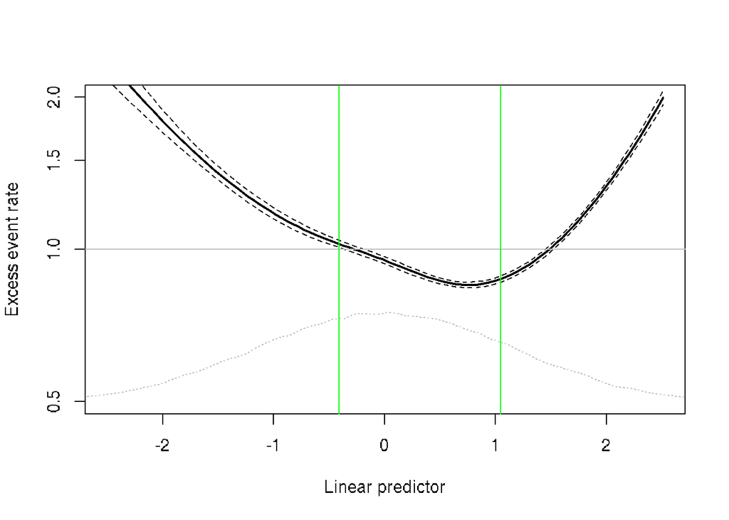

```r
calib.ph.lines <- subset(calib.ph[["plot"]]$data, Calibration == "Estimated") |> dplyr::arrange(pred) |> dplyr::mutate(lp = log(-log(1-pred)))
matplot(xx, exp(yy), type='l', lty=c(1,2,2), lwd=c(2,1,1), log='y', col=1,
        ylim=c(.5, 2),
        xlab="Linear predictor", ylab="Excess event rate")
abline(h=exp(coef(gfit1)), col='gray', lty=1)
temp <- density(dat.valid$eta, adjust=.5)
tfun <- function(y) .5 + (y-min(y))/(4*diff(range(y)))
lines(temp$x, tfun(temp$y), lty=3, col='gray')
abline(v=calib.ph.lines[min(which(calib.ph.lines$pred.obs < calib.ph.lines$pred)), "lp"], col='green', lty=1)
abline(v=calib.ph.lines[max(which(calib.ph.lines$pred.obs < calib.ph.lines$pred)), "lp"], col='green', lty=1)
```

I can sort of replicate this by grouping individuals by the linear predictor, and taking mean expected number of events from DGM, and mean predicted risk.

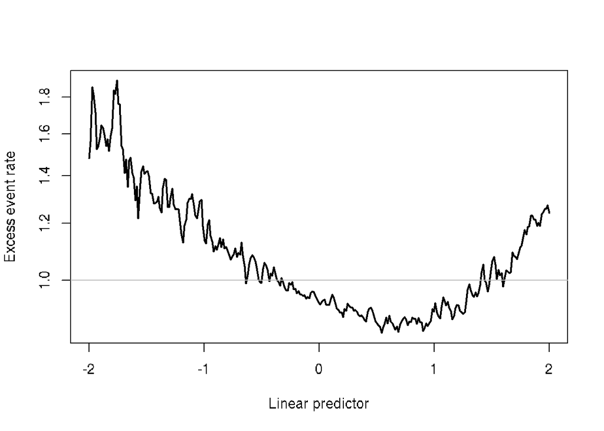

```r
### Calculate true expected number of events according to DGM
### The baseline hazard is just 1, so its 1*time
dat.valid$bhaz.pat.true <- 1*dat.valid$time

### The expected number of events is then the baseline hazard, multiplied by the exponent of the linear predictor
dat.valid$expect_true <- dat.valid$bhaz.pat.true*exp(dat.valid$true.lp)

expect_pred_group <- vector("numeric",300)
expect_true_group <- vector("numeric",300)
for (i in 1:300){
  eta.loop <- seq(-2,2,length.out = 300)[i]
  expect_pred_group[i] <- mean(dat.valid$expect1[dat.valid$eta > eta.loop-0.02 & dat.valid$eta < eta.loop+0.02])
  expect_true_group[i] <- mean(dat.valid$expect_true[dat.valid$eta > eta.loop-0.02 & dat.valid$eta < eta.loop+0.02])
}

xx <- seq(-2,2,length.out = 300)
yy <- expect_true_group/expect_pred_group

matplot(xx, yy, type='l', lty=c(1), lwd=c(2), log='y', col=1,
        #ylim=c(.5, 2),
        xlab="Linear predictor", ylab="Excess event rate")
abline(h=exp(coef(gfit1)), col='gray', lty=1)
temp <- density(dat.valid$eta, adjust=.5)
tfun <- function(y) .5 + (y-min(y))/(4*diff(range(y)))
lines(temp$x, tfun(temp$y), lty=3, col='gray')
```

```r
# matplot(exp(-0.5*exp(xx)), exp(yy), type='l', lty=c(1,2,2), lwd=c(2,1,1), log='y', col=1,
#         ylim=c(.5, 2),
#         xlab="Predicted risk", ylab="Excess event rate")
# abline(h=exp(coef(gfit1)), col='gray', lty=1)
# temp <- density(dat.valid$eta, adjust=.5)
# tfun <- function(y) .5 + (y-min(y))/(4*diff(range(y)))
# lines(temp$x, tfun(temp$y), lty=3, col='gray')
```

## 2.4 Assess calibration using grouped Poisson method

Going to split the validation dataset up by eta (the linear predictor) and do an intercept only model Poisson model, to get the observed/expected ratios. This matches very well, to be expected. But again, any proble with the Poisson approach would also be a problem here.

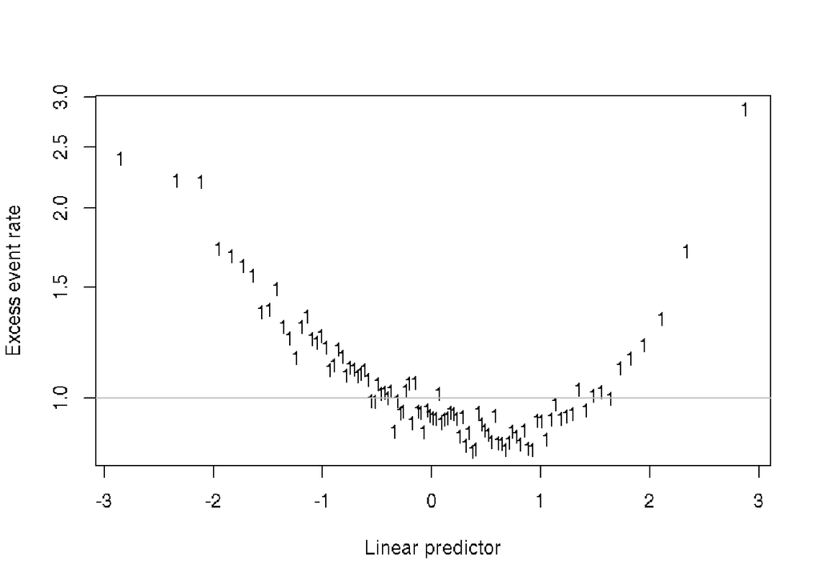

```r
lp_mean <- vector("numeric",100)
oe <- vector("numeric",100)
dat.valid.split <- split(dat.valid, cut(dat.valid$eta, quantile(dat.valid$eta, p = seq(0, 1, length.out = 101))))
for (i in 1:100){

  ### Fit calibration model for mean calibraiton
  temp_gfit1 <- glm(status ~ offset(log(expect1)), poisson, data = dat.valid.split[[i]])
  oe[i] <- exp(coef(temp_gfit1))
  lp_mean[i] <- mean(dat.valid.split[[i]][,"eta"])

}

xx <- lp_mean
yy <- oe

matplot(xx, yy, type='p', lty=c(1), lwd=c(2), log='y', col=1,
        #ylim=c(.5, 2),
        xlab="Linear predictor", ylab="Excess event rate")
abline(h=exp(coef(gfit1)), col='gray', lty=1)
temp <- density(dat.valid$eta, adjust=.5)
tfun <- function(y) .5 + (y-min(y))/(4*diff(range(y)))
lines(temp$x, tfun(temp$y), lty=3, col='gray')
```

```r
# matplot(exp(-0.5*exp(xx)), yy, type='p', lty=c(1), lwd=c(2), log='y', col=1,
#         #ylim=c(.5, 2),
#         xlab="Predicted risk", ylab="Excess event rate")
# abline(h=exp(coef(gfit1)), col='gray', lty=1)
# temp <- density(dat.valid$eta, adjust=.5)
# tfun <- function(y) .5 + (y-min(y))/(4*diff(range(y)))
# lines(temp$x, tfun(temp$y), lty=3, col='gray')
```

## 2.5 Assess calibration using kaplan-meier

Here, observed is kaplan-meier within subgroup, predicted risk is the mean predicted risk within that subgroup.

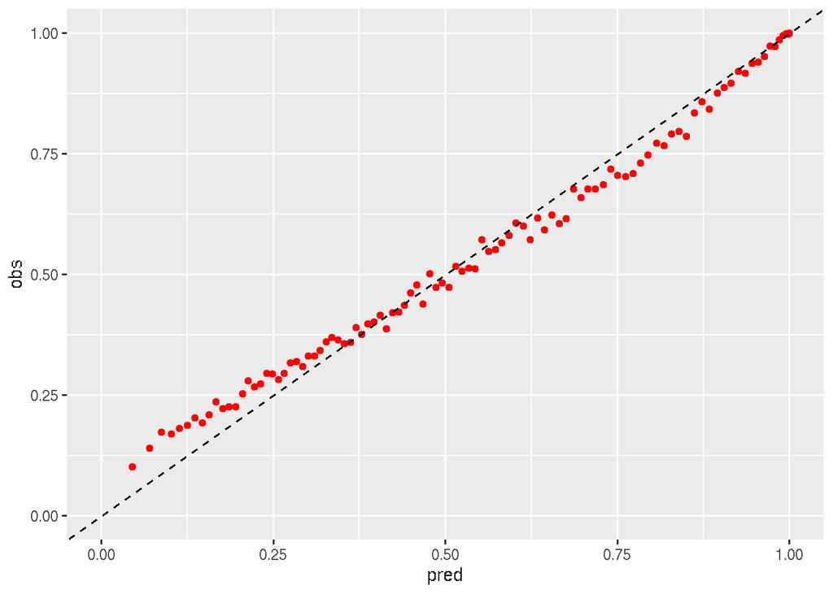

```r
km_group <- est_calib_plot_group(data = dat.valid, fit = fit.ml, bhaz = bhaz.ml, t = t.eval, n.groups = 100)
km_group[["plot"]] + xlim(c(0,1)) + ylim(c(0,1))
```

This matches our smoothed calibration curve, unsurprisingly.

## 2.6 Assess calibration using kaplan-meier to get observed vs expcted ratio

Here, we calculate kaplan-meier within each subgroup, and the mean predicted risk within each subgroup, then take the ratio to get observed/expected ratio.

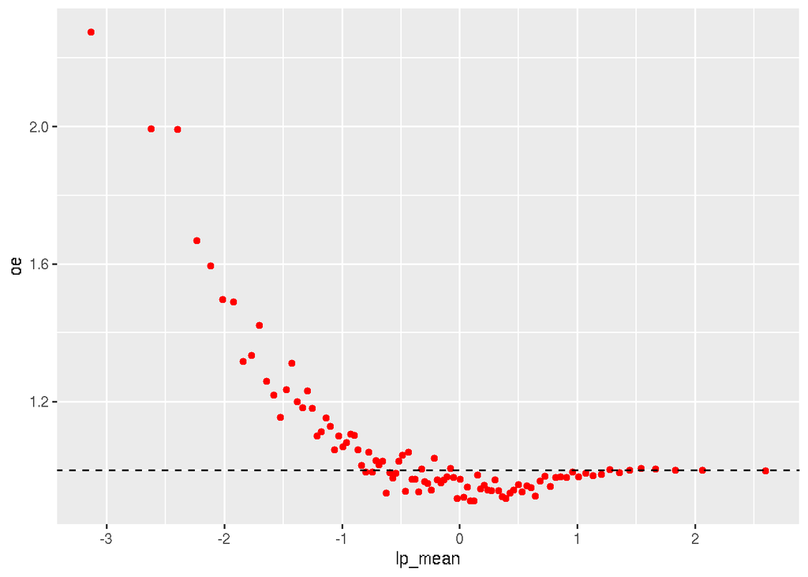

```r
est_calib_plot_group_oe_lp <- function(data, fit, bhaz, t, n.groups, surv = NULL){

  ### Get the survival probabilities
  if (is.null(surv)){
    data$surv <- as.numeric(est_surv(newdata = data, fit = fit, bhaz = bhaz, t = t))
  } else {
    data$surv <- as.numeric(surv)
  }

  ### Split data by surv
  data.split <- split(data, cut(data$surv, c(-Inf, quantile(data$surv, probs = 1:n.groups/n.groups))))

  ### Create vectors to store estimates
  obs <- vector("numeric", n.groups)
  pred <- vector("numeric", n.groups)
  lp_mean <- vector("numeric", n.groups)

  ### Run through
  for (i in 1:n.groups){

    ### Get Kaplan-Meier estimate
    survobj <- survival::survfit(survival::Surv(time, status) ~ 1, data = data.split[[i]])
    obs[i] <- 1-as.numeric(survobj$surv[max(which(survobj$time <= t))])

    ### Get predicted
    pred[i] <- 1 - (mean(data.split[[i]]$surv))

    ### Get mean of lp
    lp_mean[i] <- mean(log(-log(data.split[[i]]$surv)))
  }

  ### Get oe
  oe <- obs/pred

  ### Create plot data
  plot.data <- data.frame("oe" = oe, "lp" = lp_mean)

  ### Create plot
  plot <- ggplot2::ggplot(data = plot.data) +
    ggplot2::geom_point(ggplot2::aes(x = lp_mean, y = oe), color = "red") +
    ggplot2::geom_abline(slope = 0, intercept = 1, lty = "dashed")

  ### Create output.object
  output.object <- list("plot" = plot)

  return(output.object)

}

km_group_oe_lp <- est_calib_plot_group_oe_lp(data = dat.valid, fit = fit.ml, bhaz = bhaz.ml, t = t.eval, n.groups = 100)
km_group_oe_lp[["plot"]]
```